# Predicting the Manner of Exercise

Elhasnaoui

2024-08-21

# Introduction

This project involves analyzing data collected from accelerometers on the belt, forearm, arm, and dumbbell of six participants performing barbell lifts. The goal is to predict the manner in which the participants did the exercise using the “classe” variable.

## Load data

```r
# Load the training and test data
train_url <- "https://d396qusza40orc.cloudfront.net/predmachlearn/pml-training.csv"
test_url <- "https://d396qusza40orc.cloudfront.net/predmachlearn/pml-testing.csv"

training <- read.csv(train_url, na.strings = c("NA", "#DIV/0!", ""))
testing <- read.csv(test_url, na.strings = c("NA", "#DIV/0!", ""))

# Summary of the dataset
summary(training)
```

[output not shown]

[output cut: 289 more lines]

[output not shown]

## Data Preprocessing

```r
# Remove columns with near-zero variance
nzv <- nearZeroVar(training, saveMetrics = TRUE)
training <- training[, !nzv$nzv]

# Remove columns with missing values
training <- training[, colSums(is.na(training)) == 0]

# Remove unnecessary columns (e.g., IDs, timestamps)
training <- training %>% select(-c(X, user_name, raw_timestamp_part_1, raw_timestamp_part_2, cvtd_timestamp, num_window,))

# Ensure testing set has the same columns as the training set
testing <- testing %>% select(names(training)[-ncol(training)])
```

## Model Building

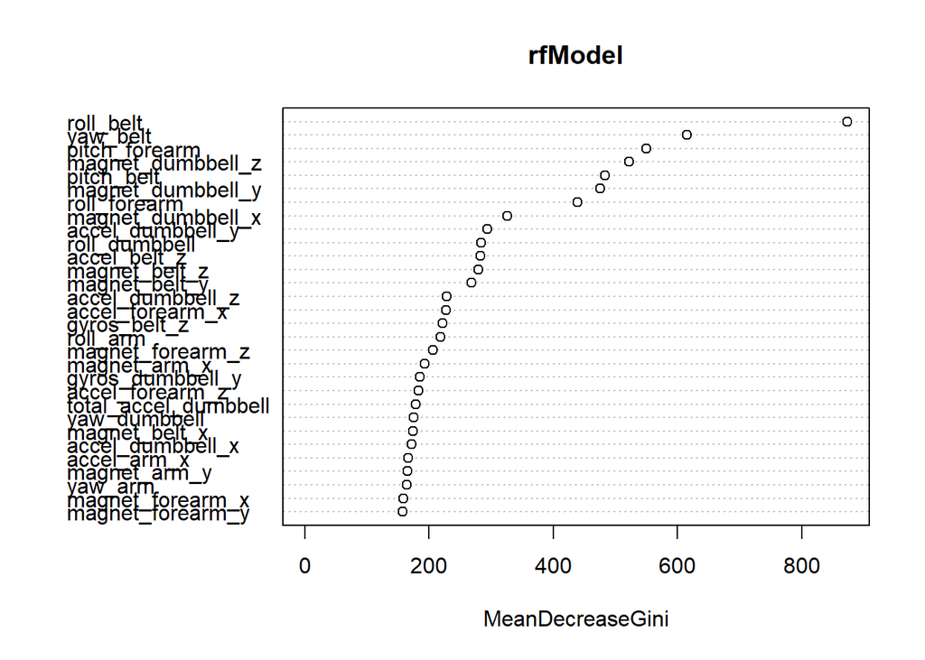

```r
# Set seed for reproducibility
set.seed(12345)

# Convert 'classe' to a factor
training$classe <- as.factor(training$classe)

# Partition the data into training and validation sets
inTrain <- createDataPartition(training$classe, p = 0.7, list = FALSE)
trainSet <- training[inTrain,]
valSet <- training[-inTrain,]

# Train a Random Forest model
rfModel <- randomForest(classe ~ ., data = trainSet)
varImpPlot(rfModel)
```

## Cross-Validation and Model Evaluation

```r
# Predict on validation set
predictions <- predict(rfModel, valSet)

# Confusion matrix and accuracy
confusionMatrix(predictions, valSet$classe)
```

```
## Confusion Matrix and Statistics
##
##           Reference
## Prediction    A    B    C    D    E
##          A 1673    4    0    0    0
##          B    1 1134    2    0    0
##          C    0    1 1024   10    0
##          D    0    0    0  954    1
##          E    0    0    0    0 1081
##
## Overall Statistics
##
##                Accuracy : 0.9968
##                  95% CI : (0.995, 0.9981)
##     No Information Rate : 0.2845
##     P-Value [Acc > NIR] : < 2.2e-16
##
##                   Kappa : 0.9959
##
##  Mcnemar's Test P-Value : NA
##
## Statistics by Class:
##
##                      Class: A Class: B Class: C Class: D Class: E
## Sensitivity            0.9994   0.9956   0.9981   0.9896   0.9991
## Specificity            0.9991   0.9994   0.9977   0.9998   1.0000
## Pos Pred Value         0.9976   0.9974   0.9894   0.9990   1.0000
## Neg Pred Value         0.9998   0.9989   0.9996   0.9980   0.9998
## Prevalence             0.2845   0.1935   0.1743   0.1638   0.1839
## Detection Rate         0.2843   0.1927   0.1740   0.1621   0.1837
## Detection Prevalence   0.2850   0.1932   0.1759   0.1623   0.1837
## Balanced Accuracy      0.9992   0.9975   0.9979   0.9947   0.9995
```

## Test Set Predictions

```r
# Predict on the test set
testPredictions <- predict(rfModel, testing)
testPredictions
```

```
##  1  2  3  4  5  6  7  8  9 10 11 12 13 14 15 16 17 18 19 20
##  B  A  B  A  A  E  D  B  A  A  B  C  B  A  E  E  A  B  B  B
## Levels: A B C D E
```

# Conclusion

## 1. Accuracy and Performance:

Accuracy: The model achieved an accuracy of 99.68%, meaning it correctly classified the manner of exercise in 99.68% of cases. This is a very high level of accuracy. Kappa: The Kappa statistic is 0.9959, which indicates almost perfect agreement between the predicted and actual classes. A Kappa value close to 1 suggests that the model is performing exceptionally well. 95% Confidence Interval (CI): The confidence interval for accuracy is (0.995, 0.9981), showing that even in the worst case, the model is highly accurate.

## 2. Class-wise Performance:

Sensitivity (Recall): Sensitivity values are near 100% for all classes, indicating that the model is highly effective at correctly identifying each class (A-E). The lowest sensitivity is for Class D at 98.96%, but even this is very high. Specificity: Specificity values are also near 100% for all classes, meaning the model rarely misclassifies other classes as a specific class. Pos Pred Value (Precision): The precision is also high across all classes, showing that when the model predicts a class, it’s almost always correct. Balanced Accuracy: The balanced accuracy, which is the average of sensitivity and specificity, is also close to 100% for all classes.

# Appendix

R Packages Used: randomForest: For building the Random Forest model. caret: For data partitioning and model evaluation. dplyr: For data manipulation.